# Price-Increase-Initial

Mike Kaminski

2023-03-13

# Setup

```r
library(zoo)
library(lares)
library(yfR)
library(readr)
library(tidyr)
library(dplyr)
library(CausalImpact)
library(TTR)
```

# Stock Prices for Baseline

## Gets a list of all the tickers in the S&P500

```r
# set.seed(1234)
#
# n_tickers <- 500
# df_sp500 <- yf_index_composition("SP500")
# rnd_tickers <- base::sample(df_sp500$ticker, n_tickers)
```

##Extracts historical prices from yahoo finance

```r
# this was run once for the analysis, but can be run again if needed

# df_yf <- yf_get(tickers = rnd_tickers,
#                 first_date = '2020-01-02',
#                 last_date = Sys.Date())
# head(df_yf)
```

##Creates Moving Averages

```r
#Removes unnecessary columns and adds a 5, 10, and 20 day moving average.  These will come into play later in the code

# df_stock_prices_ma <- df_yf %>%
#   select(ticker, ref_date, price_close) %>%
#   group_by(ticker) %>%
#   mutate(mov_avg5 = SMA(price_close, n =5)) %>%
#   mutate(mov_avg10 = SMA(price_close, n =10)) %>%
#   mutate(mov_avg20 = SMA(price_close, n =20))%>%
#   mutate(ref_date = as.Date(ref_date)) %>%
#   mutate(price_close = as.numeric(price_close)) %>%
#   ungroup()
```

##saves

##imports saved stock data

```r
df_stock_prices_ma <- read.csv(file.choose())

df_stock_prices_ma1 <- df_stock_prices_ma %>%
  select(-c(X)) %>%
  mutate(ref_date = as.Date(ref_date))
```

## Missing Data

- Stocks are only priced on days the markets are open, so a sequence of dates has been created to account for the days when there wasn’t a closing price.

```r
df_date_list <- df_stock_prices_ma1 %>%
  group_by(ticker) %>%
  complete(ref_date = seq.Date(as.Date('2019-12-29'), Sys.Date(), by="day")) %>%
  ungroup()
```

- Replaces NAs with 10dma.
- 5-day or 20-day moving average can be used as well
- Sales data starts on Feb 1 2020

```r
df_stock_prices_ma_clean <- df_date_list %>%
  group_by(ticker) %>%
  fill(mov_avg10, .direction = "downup")  %>%
  mutate(price_close = ifelse(is.na(price_close), mov_avg10, price_close))  %>%
  select(c(ticker,ref_date,price_close)) %>%
  filter(ref_date >= '2020-02-01') %>% # first day of sales data
  mutate(price_close = round(price_close,2))%>%
  ungroup()
```

## 5dma Stock Price data

- Alternatively, a df is created based just on the 5-day moving average of the share price - 1 week

```r
df_stock_prices_5dma <- df_date_list %>%
  group_by(ticker) %>%
  fill(mov_avg5, .direction = "downup")  %>%
  select(c(ticker,ref_date,mov_avg5)) %>%
  filter(ref_date >= '2020-02-01') %>% #most recent sales data
  mutate(mov_avg5 = round(mov_avg5,2)) %>%
  select(ref_date, ticker, mov_avg5) %>%
  as.data.frame()
```

# Sales Data

## Import Data

```r
df_sales <- read.csv(file.choose())
```

## Converts sales_df date to appropriate date forma and creates a 7days moving average for sales

```r
df_sales$Date <- as.Date(df_sales$Date, format = "%m/%d/%Y")
df_sales_7dma <- df_sales %>%
  mutate(mov_avg7 = round(SMA(Sales, n =7),2))
```

## merges daily sales and the daily stocks data

```r
df_final_daily <- merge(df_stock_prices_ma_clean, df_sales, by.x='ref_date',by.y='Date', all.x=TRUE) %>%
  pivot_wider(names_from = ticker, values_from = price_close) %>%
  filter(Sales >=0) %>%
  as.data.frame()
```

## merges the 7dma sales and the daily stocks data

```r
df_final_7dma_daily <- merge(df_stock_prices_ma_clean, df_sales_7dma, by.x='ref_date',by.y='Date', all.x=TRUE) %>%
  select(-c(Sales)) %>%
  pivot_wider(names_from = ticker, values_from = price_close) %>%
  filter(mov_avg7 >=0) %>%
  as.data.frame()
```

## merges the 7dma sales and 5dma stocks data

```r
df_final_7dma_5dma <- merge(df_stock_prices_5dma, df_sales_7dma, by.x='ref_date',by.y='Date', all.x=TRUE) %>%
  select(-c(Sales)) %>%
  pivot_wider(names_from = ticker, values_from = mov_avg5) %>%
  filter(mov_avg7 >=0)%>%
  as.data.frame()
```

## In order to create a synthetic control group aka a baseline, we want to see which securities are most correlated to the number of sales. Actual daily values are used initially, but log values as well as 7dma for sales and 5dma for stocks will be reviewed

```r
m <- df_final_daily[,-1]
a <- corr_var(m,
              Sales,
              top = 25,
              #max_pvalue = 0.05
              )
```

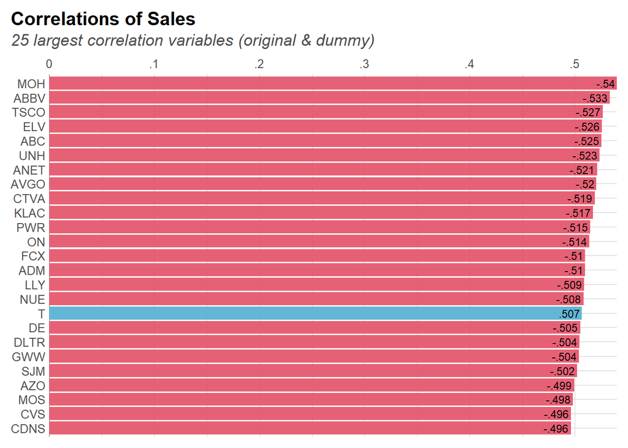

```r
plot(a, cex = .5,cex.axis=.5)
```

#### Correlations don’t look too strong, the most correlated is MOH with a corr of -0.54. Will try with log values of sales

## Log values of daily sales and stock prices

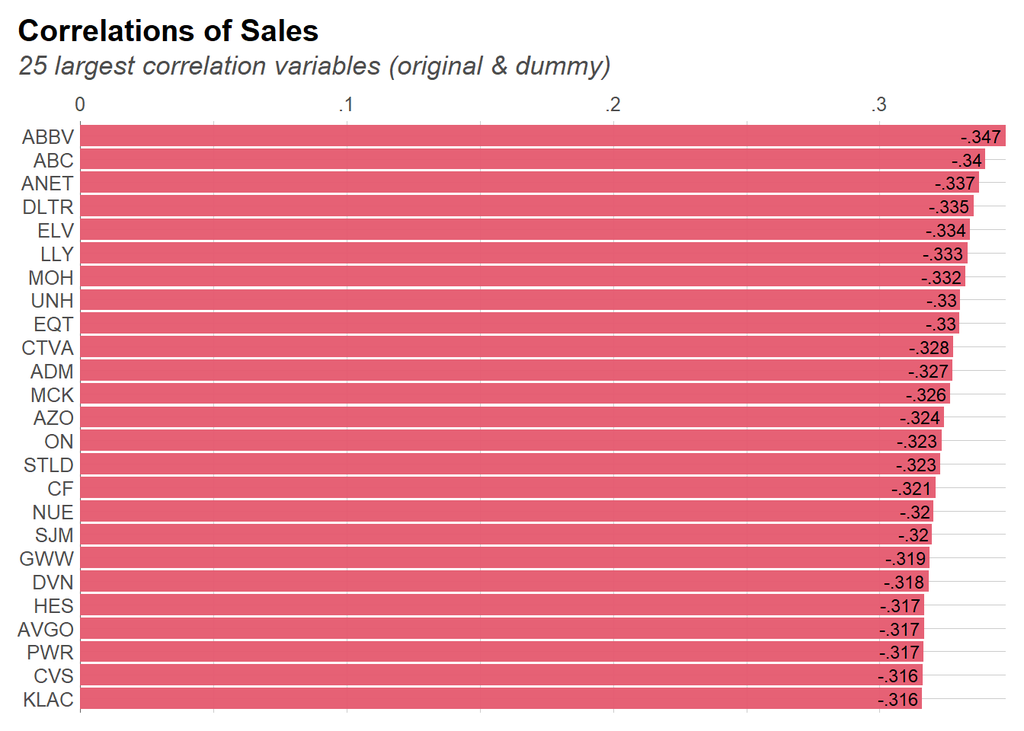

```r
m_log <- log(df_final_daily[,-1])
a_log <- corr_var(m_log,
              Sales,
              top = 25,
              #max_pvalue = 0.05
              )
plot(a_log, cex = .5,cex.axis=.5)
```

#### These results are actually worse than before. There might be too much variablity in the daily sales data, so willcheck against the 7dma and the daily prices

## 7dma Sales and daily stock prices

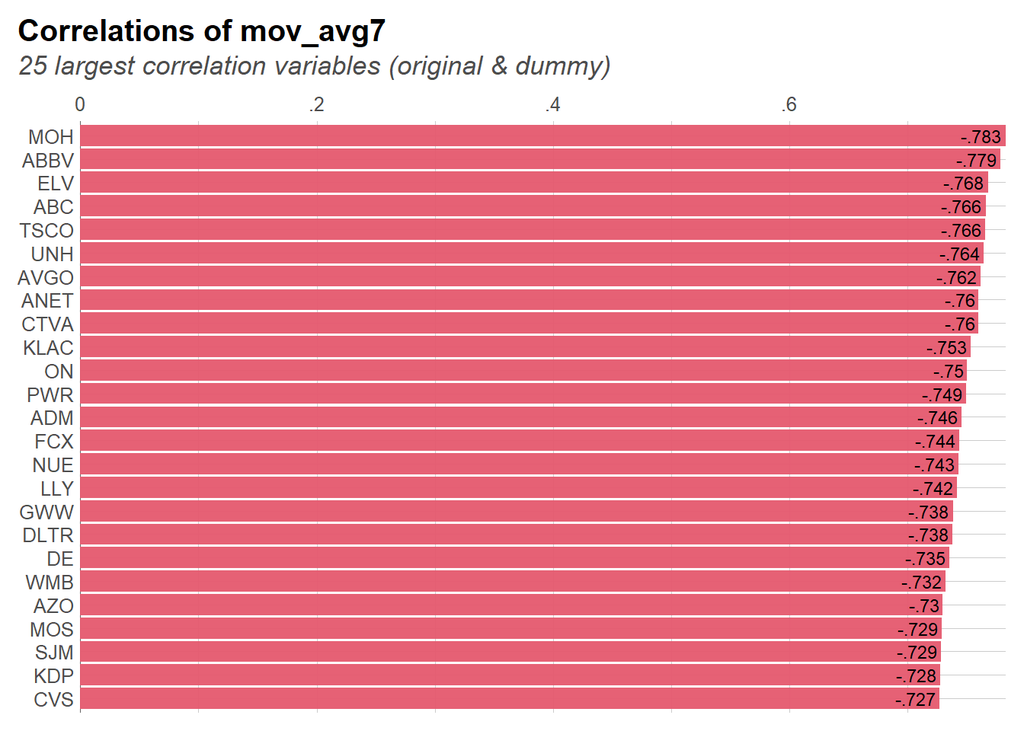

```r
m_7dma <- df_final_7dma_daily[,-1]
a_7dma <- corr_var(m_7dma,
              mov_avg7,
              top = 25,
              #max_pvalue = 0.05
              )
plot(a_7dma, cex = .5,cex.axis=.5)
```

#### These results look a lot better. The top 25 range from -.783 to -.727.

## 7dma sales and 5dma stock prices

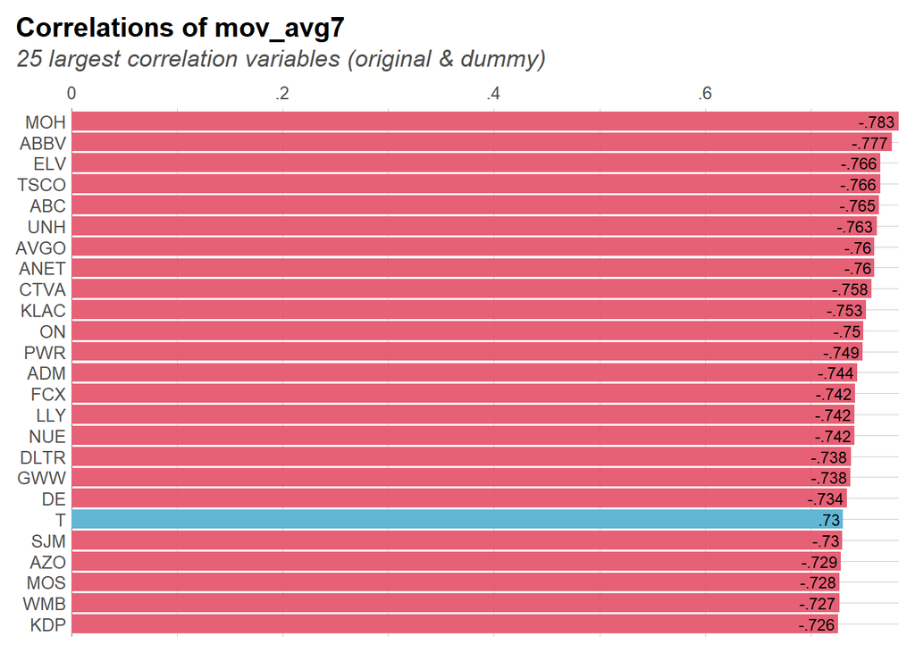

```r
m_7dma_5dma <- df_final_7dma_5dma[,-1]
a_7dma_5dma <- corr_var(m_7dma_5dma,
              mov_avg7,
              top = 25,
              #max_pvalue = 0.05
              )
plot(a_7dma_5dma, cex = .5,cex.axis=.5)
```

####Look at the top 100 for 7dma and 5dma

```r
m_7dma_5dma <- df_final_7dma_5dma[,-1]
a_7dma_5dma <- corr_var(m_7dma_5dma,
              mov_avg7,
              top = 100,
              #max_pvalue = 0.05
              )
# plot(a_7dma, cex = .5,cex.axis=.5) #the plot looks messy, but the values are included below
a_7dma_5dma$data$corr
```

```
##   [1] -0.783229 -0.776756 -0.766169 -0.765919 -0.764824 -0.762551 -0.760110
##   [8] -0.759978 -0.757942 -0.752804 -0.749777 -0.749420 -0.744344 -0.742274
##  [15] -0.741613 -0.741598 -0.738045 -0.737573 -0.734438  0.730340 -0.730185
##  [22] -0.728845 -0.727651 -0.727163 -0.726183 -0.724881 -0.723681 -0.722660
##  [29] -0.722031 -0.722004 -0.721174 -0.720467 -0.719556 -0.719462 -0.718680
##  [36] -0.718197 -0.716026 -0.715124 -0.714362 -0.712371 -0.711480 -0.707591
##  [43] -0.705925 -0.704662 -0.704246 -0.703952 -0.702980 -0.699347 -0.699149
##  [50] -0.698740 -0.698544 -0.698291 -0.697959 -0.696657 -0.695790 -0.695183
##  [57] -0.692312 -0.691311 -0.691137 -0.688381 -0.686310 -0.685495 -0.682283
##  [64] -0.681914 -0.681529 -0.681186  0.680862 -0.680487 -0.680459 -0.679738
##  [71] -0.678393 -0.677099 -0.676551 -0.675531 -0.674642 -0.674022 -0.673733
##  [78] -0.673552 -0.673017 -0.672046 -0.670992 -0.669388 -0.669359 -0.668979
##  [85] -0.667587 -0.666166 -0.665745 -0.665608 -0.665517 -0.663580 -0.663078
##  [92] -0.662878 -0.661908 -0.654282 -0.652571 -0.651751 -0.651724 -0.650237
##  [99] -0.649320 -0.648704
```

```r
a_7dma_5dma$data$variables
```

```
##   [1] "MOH"  "ABBV" "ELV"  "TSCO" "ABC"  "UNH"  "AVGO" "ANET" "CTVA" "KLAC"
##  [11] "ON"   "PWR"  "ADM"  "FCX"  "LLY"  "NUE"  "DLTR" "GWW"  "DE"   "T"
##  [21] "SJM"  "AZO"  "MOS"  "WMB"  "KDP"  "CVS"  "STLD" "CDNS" "SNPS" "RJF"
##  [31] "TRV"  "AJG"  "FANG" "JBHT" "AMP"  "ORLY" "JNJ"  "BKR"  "KR"   "PXD"
##  [41] "SCHW" "JNPR" "EOG"  "HAL"  "MRO"  "DVN"  "ODFL" "CB"   "MET"  "HES"
##  [51] "TRGP" "KHC"  "FTNT" "CF"   "COST" "MCK"  "ULTA" "HSY"  "IRM"  "LIN"
##  [61] "PFE"  "AAPL" "PAYX" "AFL"  "URI"  "PFG"  "VTRS" "CVX"  "CAT"  "ALB"
##  [71] "EQT"  "PEP"  "CNC"  "COP"  "TMO"  "IT"   "ADP"  "LKQ"  "KEYS" "HPQ"
##  [81] "PGR"  "MMC"  "GD"   "APH"  "XOM"  "ADI"  "GPC"  "RF"   "MPC"  "DG"
##  [91] "STZ"  "WRB"  "SEE"  "ENPH" "EXC"  "CI"   "MTD"  "PKG"  "SNA"  "WAB"
```

## log of the 7dma sales and 5dma stock prices

[figure not shown]

```r
m_7dma_5dma_log <- log(df_final_7dma_5dma[,-1])
a_7dma_5dma_log <- corr_var(m_7dma_5dma_log,
              mov_avg7,
              top = 100,
              #max_pvalue = 0.05
              )
plot(a_7dma_5dma_log, cex = .5,cex.axis=.5) #the plot looks messy, but the values are included below
```

```r
cor_log_7 <- a_7dma_5dma_log$data$corr
stock_log_7 <-a_7dma_5dma_log$data$variables
log_7 <- data.frame(col1 = stock_log_7,col2 =cor_log_7) #creates a dataframe to review
head(log_7)
```

```
##   col1      col2
## 1 ABBV -0.848726
## 2  ABC -0.835762
## 3 ANET -0.819266
## 4  ELV -0.815438
## 5 DLTR -0.813811
## 6  LLY -0.813239
```

```r
which(abs(a_7dma_5dma_log$data$corr) >= (0.695))
```

```
##  [1]  1  2  3  4  5  6  7  8  9 10 11 12 13 14 15 16 17 18 19 20 21 22 23 24 25
## [26] 26 27 28 29 30 31 32 33 34 35 36 37 38 39 40 41 42 43 44 45 46 47 48 49 50
## [51] 51 52 53 54 55 56 57 58 59 60 61 62 63 64 65 66 67 68 69 70 71 72 73 74 75
## [76] 76 77 78 79 80 81 82 83 84 85 86
```

```r
# mean of each
mean(abs(a_7dma_5dma$data$corr))
```

```
## [1] 0.7026227
```

```r
mean(abs(a_7dma_5dma_log$data$corr))
```

```
## [1] 0.7461005
```

#### The log of 7dma and 5dma have a larger average correlation than without log, so these varibles will be used. Just need to remember to take reverse log out of the final values